# COMP163 Project

Ben Ung

2025-02-28

# Introduction

https://catalog.data.gov/dataset/motor-vehicle-collisions-crashes

For this project, I analyzed the above data set, which consisted of record of motor vehicle crashes from 2012 to February 2025 in New York City. The data set records each motor vehicle incident as well as the time, location, vehicles involved, and reasons for the crash. My motivation for this data set was that I had hoped to analyze which specific model of car was responsible for car crashes, but the data was too messy to do so. I also dislike Honda Civics and Nissan Altimas and hoped to statistically prove my vendetta against them. Aside from my personal beliefs, I did think that this data was interesting and would maybe provide myself some interesting insights into traffic data.

To start, this data set was extremely messy and I needed clean up many of the categorical values. Using ChatGPT, I classified the Vehicle columns and contributing factor columns into a smaller set of categories that would be easier to analyze.

## Transform Vehicle Column

```r
normalize_text <- function(text) {
  text <- tolower(text)
  text <- gsub("[^a-z0-9\\s-]", "", text)
  trimws(text)
}

# Define classification categories
vehicle_map <- list(
  "passenger" = c("car", "suv", "convertible", "coupe", "sedan", "minivan", "van", "pickup","stationwagonsportutilityvehicle"),
  "public_transport" = c("bus", "school bus", "transit", "livery", "shuttle"),
  "two_wheeled" = c("motorcycle", "moped", "scooter", "bicycle", "bike", "e-bike", "e-scooter"),
  "emergency" = c("ambulance", "fire truck", "fire engine", "police", "fdny", "ems", "rescue"),
  "commercial_delivery" = c("truck", "box truck", "pickup truck", "cargo", "delivery", "freight", "semi", "big rig"),
  "construction_heavy" = c("bulldozer", "excavator", "crane", "cement mixer", "forklift", "dump truck", "tractor"),
  "government_utility" = c("sanitation", "postal", "utility", "fdny", "nypd", "gov", "city vehicle"),
  "specialty" = c("golf cart", "limo", "armored truck", "horse carriage", "hearse", "snowplow", "street sweeper"),
  "N/A" = c("")
)

map_vehicle <- function(vehicle) {
  for (category in names(vehicle_map)) {
    if (vehicle %in% vehicle_map[[category]]) {
      return(category)
    }
  }
  return("Other")  # Default category if no match is found
}
motor_crashes$normalized_vehicles_1 = normalize_text(motor_crashes$VEHICLE.TYPE.CODE.1)
motor_crashes$normalized_vehicles_2 = normalize_text(motor_crashes$VEHICLE.TYPE.CODE.2)

motor_crashes = motor_crashes %>% mutate(vehicle_class_1 = sapply(normalized_vehicles_1,map_vehicle),
                                         vehicle_class_2 = sapply(normalized_vehicles_2,map_vehicle))
```

I repeated the same process for the contributing factors.

## Transform Contributing Factors

```r
category_mapping <- list(
  "Substance Impairment" = c("Alcohol Involvement", "Drugs (illegal)", "Prescription Medication"),
  "Reckless Driving" = c("Aggressive Driving/Road Rage", "Following Too Closely", "Unsafe Speed",
                         "Unsafe Lane Changing", "Passing Too Closely", "Passing or Lane Usage Improper"),
  "Driver Distraction" = c("Driver Inattention/Distraction", "Cell Phone (hand-held)", "Cell Phone (hands-free)",
                           "Texting", "Using On Board Navigation Device", "Other Electronic Device",
                           "Eating or Drinking", "Passenger Distraction", "Outside Car Distraction"),
  "Driver Error" = c("Driver Inexperience", "Reaction to Other Uninvolved Vehicle", "Reaction to Uninvolved Vehicle"),
  "Fatigue" = c("Fatigued/Drowsy", "Fell Asleep"),
  "Medical Conditions" = c("Lost Consciousness", "Illness", "Physical Disability"),
  "Vehicle Defects" = c("Accelerator Defective", "Brakes Defective", "Steering Failure", "Headlights Defective",
                        "Other Lighting Defects", "Tinted Windows", "Tire Failure/Inadequate", "Tow Hitch Defective"),
  "Roadway Defects" = c("Lane Marking Improper/Inadequate", "Pavement Defective", "Shoulders Defective/Improper",
                        "Traffic Control Device Improper/Non-Working"),
  "Environmental Factors" = c("Animals Action", "Obstruction/Debris", "Glare", "View Obstructed/Limited",
                              "Windshield Inadequate", "Pedestrian/Bicyclist/Other Pedestrian Error/Confusion"),
  "N/A" = c(""),
  "Other" = c()  # Placeholder for any uncategorized reasons
)
map_category <- function(reason) {
  for (category in names(category_mapping)) {
    if (reason %in% category_mapping[[category]]) {
      return(category)
    }
  }
  return("Other")  # Default category if no match is found
}

motor_crashes = motor_crashes %>% mutate(factor1 = sapply(CONTRIBUTING.FACTOR.VEHICLE.1,map_category),
                                     factor2 = sapply(CONTRIBUTING.FACTOR.VEHICLE.2,map_category)
                                     )
```

In addition to the vehicle classes and the contributing factors, I also wanted to modify the recorded times into a numerical variable that I could plot. The following code snippet shows what I did to convert the original date strings into numerical values and POSIXlt.

## Fix Times

```r
full_date = paste(motor_crashes$CRASH.DATE,motor_crashes$CRASH.TIME)
motor_crashes$corrected_datetime = strptime(full_date, "%m/%d/%Y %H:%M")
motor_crashes = motor_crashes %>% mutate(year = as.integer(format(corrected_datetime,"%Y")),
                                         hour = corrected_datetime$hour,
                                         minute = corrected_datetime$min,
                                         time_hrs = hour + minute/60)
```

I decided to add some extra binary variables to add some extra level of complexity or areas of analysis that I thought would be good to take a look at as well. Unfortunately, I did not get the chance to analyze the data using all of these extra variables.

## Add Extra Variables

```r
motor_crashes = motor_crashes %>% mutate(hasDeath = NUMBER.OF.PERSONS.KILLED > 0,
                                         hasInjury = NUMBER.OF.PERSONS.INJURED > 0,
                                         multiVehicleCrash = VEHICLE.TYPE.CODE.1 != "" & VEHICLE.TYPE.CODE.2 != "" & VEHICLE.TYPE.CODE.3 != "" | VEHICLE.TYPE.CODE.4 != "" | VEHICLE.TYPE.CODE.5 != "")
```

The first plot I wanted to examine was regular scatter plot of the latitude and longitude variables of the data. Obviously on a set of regular axes, the latitude and longitude would not provide any real value. However, I did recall that in a previous visualization assignment, I saw that it was possible to plot coordinates on a geographic map. At first, I plotted the entire data set on the same map and it produced a giant blob of data points. To create a better looking plot of the data points, I filtered the data points to show motor crashes in New York City in January 2025.

## Plot Google Map

```r
Newyork = geocode("New York City")
```

[figure not shown]

```r
hybrid_map = qmap("New York City", source="google",maptype="hybrid", zoom = 11)
motor_crash_2025 = motor_crashes %>% mutate(month = as.integer(format(corrected_datetime,"%m"))) %>% filter(year == 2025 & month == 1 & vehicle_class_1 != "N/A")
hybrid_map + geom_point(data=motor_crash_2025,aes(x=LONGITUDE,y=LATITUDE,colour = vehicle_class_1))+ geom_encircle(data = motor_crash_2025, aes(x=LONGITUDE,y=LATITUDE)) +labs(title = "All Motor Crashes in January 2025")
```

Next, I wanted to examine the distribution between the total number of crashes per hour of the day in the data set. I plotted the numerical value of hour, which range from 0 to 24, with the count of data points that fall under each hour. I produced the following plot and added some color to show which factors were most prevalent during each hour of the day.

## Histogram of Crash Times

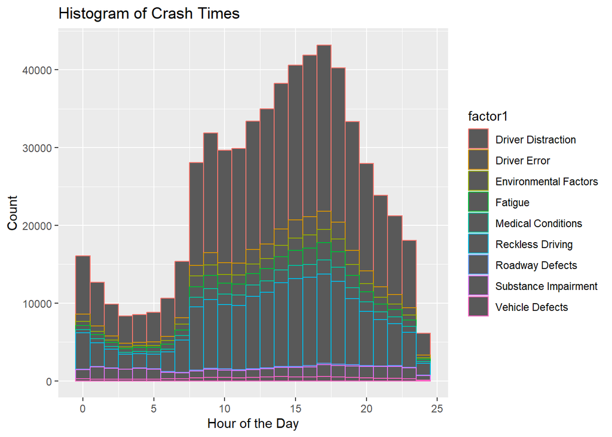

```r
filter(motor_crashes, factor1 != "Other" & factor1 != "N/A") %>%
  mutate(hour = corrected_datetime$hour,
         minute = corrected_datetime$min) %>%
  ggplot(aes(x = hour + minute / 60, color = factor1)) + geom_histogram(binwidth = 1) +
  labs(title = "Histogram of Crash Times", x = "Hour of the Day", y = "Count")
```

Looking at this histogram, we see that the most car crashes occur during the 5 PM rush hour. This makes sense as many people are impatient trying to get home and rush through traffic. Another interesting point we can take from this histogram is that distracted driving and reckless driving are the most common factors that people get into a car crash for. Using this observation from the previous histogram, I took a closer look at the distribution of distracted driving accidents.

## Histogram of Distracted Driving Accidents

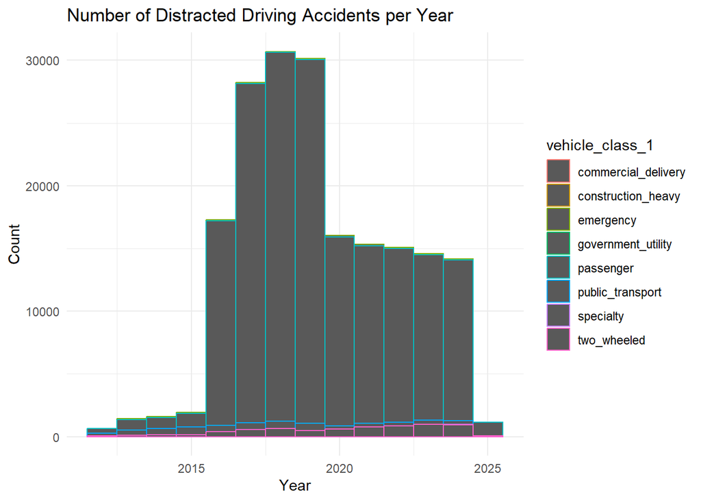

```r
filter(motor_crashes,factor1 == "Driver Distraction" & vehicle_class_1 != "N/A" & vehicle_class_1 != "Other") %>%
  ggplot(aes(x = year, color = vehicle_class_1)) + geom_histogram(binwidth = 1) +
  labs(title = "Number of Distracted Driving Accidents per Year", x = "Year", y = "Count") +
  theme_minimal()
```

Looking at this histogram, which is colored by vehicle, we see that passenger cars are the common vehicle that are involved in distracted driving incidents. This makes sense since passenger vehicle make up a pretty large portion of the entire data set. From the previous visualizations, we can conclude that passenger vehicles are the most common vehicles involved in distracted driving accidents and that distracted and reckless driving are the most frequent reasons for motor accidents.